# O Supremo exerce o seu papel contramajoritário nas ações sobre a Covid-19?

19/12/2020

## **Objeto**

Examinar o fenômeno da judicialização da política a partir das ações referentes à pandemia da Covid-19 julgadas pelo STF, utilizando como conceito de judicialização o fato do STF poder exerce um papel contramajoritário, o que legitimaria a sua interferência no desenho e na implementação da política pública acerca da Covid-19.

## **Objetivos: Pergunta da Pesquisa e Hipótese Nula**

- **O STF assume um papel contramajoritário, ou seja, interfere na política pública traçada pelos poderes majoritários, ao decidir sobre ações referentes à Covid-19?**
- A hipótese nula (H0) seria a de que a nossa corte constitucional, diferentemente dos outros poderes da República, não seria capaz de desenvolver, monitorar e adaptar políticas públicas, ou seja, a de que ela tem dificuldades de se contrapor aos poderes majoritários.

## **Justificativa**

- As pesquisas acadêmicas sobre o Poder Judiciário vêm evidenciando cada vez mais a interferência desse poder na elaboração de políticas públicas.

- Existe o reconhecimento de que as cortes constitucionais seriam um guardião importante da Constituição, simbolo da soberania popular, exercendo uma missão contramajoritária ao proteger minorias da “tirania” das maiorias parlamentares.

- Essa função legitimaria a corte constitucional como formuladora de política pública.

- Entretanto não há como considerar os tribunais constitucionais, agindo como formulador de política públicas, totalmente alienados das alianças políticas existentes que, em tese, representam as maioria.

- Essa pesquisa pretende examinar esse papel contramajoritário do STF no âmbito da política pública relativa à Covid-19.

## Método: Dados 1

A pesquisa emprega uma metodologia quantitativa, utilizando como fonte de dados o sítio do STF ([link](https://transparencia.stf.jus.br/single/?appid=615fc495-804d-409f-9b08-fb436a455451&sheet=260e1cae-f9aa-44bb-bbc4-9d8b9f2244d5&opt=nointeraction&select=clearall)). Os dados são relativos às ações (decisões e despachos) direta e indiretamente envolvendo a Covid-19 submetidas à corte constitucional durante o exercício de 2020 (posição do dia 10/11/2020).

## Método: Dados 2

O banco de dados do STF apresenta 10 (dez) variáveis nomeadas como: Processo, Classe, Número do Processo, Data Atuação, Relator, Data decisão, Decisão, Assunto, Link Processo e Em Tramitação. Para a consecução desta pesquisa, constrói-se um banco de dados simplificado também em .xls, no qual fazem parte as seguintes variáveis: Processo, Classe, Relator, Decisao (simplificada), Assunto (simplificado), Tempo_decisao (Data decisão - Data Atuação) e Comport_Min, referentes apenas às ações de controle direto de constitucionalidade (STF_Trabalho_final4).

## Método: Dados 3

Descreve-se as variáveis constantes do banco de dados simplificado a partir do carregamento deste e dos pacotes que serão empregados na pesquisa, aliado a fixação do diretório de trabalho.

```
## Rows: 234
## Columns: 7
## $ Processo      <chr> ...
## $ Classe        <chr> ...
## $ Relator       <chr> ...
## $ Decisao       <dbl> ...
## $ Assunto       <chr> ...
## $ Tempo_decisao <dbl> ...
## $ Comport_Min   <dbl> ...
```

```
## # A tibble: 5 x 5
##   Classe Decisao Assunto                Tempo_decisao Comport_Min
##   <chr>    <dbl> <chr>                          <dbl>       <dbl>
## 1 ADI          1 DIREITO ADMINISTRATIVO          1175           1
## 2 ADI          1 DIREITO ADMINISTRATIVO          1138           1
## 3 ADI          1 DIREITO TRIBUTÁRIO              1065           1
## 4 ADI          1 DIREITO TRIBUTÁRIO              1089           1
## 5 ADI          1 DIREITO TRIBUTÁRIO              1121           1
```

## Método: A Variável Independente (latente)

Estrutura-se uma variável *dummy* **Comport_Min**, representativa de uma decisão majoritária ou contramajoritária do STF, da seguinte forma:

A dummy Comport_Min assume o valor 1, representando uma decisão contramajoritária, quando o relator da matéria referente à Covid-19 for um dos seguintes ministros: MARCO AURÉLIO, EDSON FACHIN, CARMEM LÚCIA, ROBERTO BARROSO, ROSA WEBER e LUIZ FUX;

A dummy Comport_Min assume o valor 0, identificando-a como majoritária, quando o relator da matéria referente à Covid-19 for um dos seguintes ministros: GILMAR MENDES, DIAS TOFFOLI, ALEXANDRE DE MORAES, RICARDO LEWANDOSWSKI e NUNES MARQUES.

## Método: O construto da variável latente

A construção da variável adotou o comportamento de cada um dos ministros na votação da Ação Direta de Inconstitucionalidade sobre a possibilidade de nova eleição dos atuais presidentes das duas casas do Congresso em legislatura subsequente. Tendo em vista que o texto constitucional é cristalino no sentido de proibir tal prática, entende-se que os ministros que votaram a favor da possibilidade de reeleição seriam aqueles que decidem ou tendem a decidir de forma majoritária, ou seja, acompanhando o desejo e manifestação da Câmara e do Senado de que isso seria possível. De forma contrária, os ministros que votaram contra a vontade das duas casas majoritárias, manifestariam ou tendem a manifestar um posicionamento contramajoritário.

## Método: Comportamento da variável latente frente a variável independente (Decisao)

Registra-se abaixo o comportamento da variável latente (Comport_M) no banco de dados simplificado em relação a variável binária (Sucesso/Insucesso) decisão (Decisao).

```r
STF_trabalho_final %>% xtabs(~STF_trabalho_final$Decisao + STF_trabalho_final$Comport_Min,data=.)
```

```
##                           STF_trabalho_final$Comport_Min
## STF_trabalho_final$Decisao  0  1
##                          0 36 46
##                          1 56 96
```

## Método: Modelo e concretização da Hipótese nula

Iremos responder a pergunta da pesquisa a partir da equação estabelecida abaixo:

**Decisao = b0 + b1Comport_Min**

A HIPÓTESE (H0) seria a de que os ministros do STF decidem as ações relativas à Covid-19 em sede das ações de controle direto de constitucionalidade em sintonia com os poderes majoritários. Ou seja, testa-se a hipótese de que os parâmetros b0 e b1 sejam iguais a zero a um nível de significância de 95%. Isso porque numa regressão com apenas uma variável categórica binária (comportamento do ministro do STF) a influência desta sobre a variável dependente (Decisão) é dada por b0 (comportamento majoritário do STF) e por b0+b1 (comportamento contramajoritário do STF).

## Análise Descritiva 1

```
##                           STF_trabalho_final$Classe
## STF_trabalho_final$Decisao ADI ADO ADPF
##                          0  52   2   28
##                          1 105   0   47
```

```
## # A tibble: 12 x 5
## # Groups:   Relator [12]
##    Relator                    ADI Outras total proporcao
##    <chr>                    <dbl>  <dbl> <dbl>     <dbl>
##  1 MIN. ROSA WEBER             23      2    25     0.92
##  2 MIN. RICARDO LEWANDOWSKI    18      3    21     0.857
##  3 MIN. MARCO AURÉLIO          65     17    82     0.793
##  4 MIN. ALEXANDRE DE MORAES    20     15    35     0.571
##  5 MIN. GILMAR MENDES          11      9    20     0.55
##  6 MIN. CÁRMEN LÚCIA            1      1     2     0.5
##  7 MIN. DIAS TOFFOLI            7      8    15     0.467
##  8 MIN. ROBERTO BARROSO        10     14    24     0.417
##  9 MIN. EDSON FACHIN            2      5     7     0.286
## 10 MIN. CELSO DE MELLO          0      1     1     0
## 11 MIN. LUIZ FUX                0      1     1     0
## 12 MIN. NUNES MARQUES           0      1     1     0
```

## Análise Descritiva 2

```
## # A tibble: 12 x 5
## # Groups:   Relator [12]
##    Relator                  Favoravel nao_Favoravel total proporcao
##    <chr>                        <dbl>         <dbl> <dbl>     <dbl>
##  1 MIN. ROSA WEBER                 22             3    25     0.88
##  2 MIN. ROBERTO BARROSO            21             3    24     0.875
##  3 MIN. EDSON FACHIN                6             1     7     0.857
##  4 MIN. DIAS TOFFOLI               12             3    15     0.8
##  5 MIN. GILMAR MENDES              14             6    20     0.7
##  6 MIN. ALEXANDRE DE MORAES        20            15    35     0.571
##  7 MIN. MARCO AURÉLIO              46            36    82     0.561
##  8 MIN. CÁRMEN LÚCIA                1             1     2     0.5
##  9 MIN. RICARDO LEWANDOWSKI        10            11    21     0.476
## 10 MIN. CELSO DE MELLO              0             1     1     0
## 11 MIN. LUIZ FUX                    0             1     1     0
## 12 MIN. NUNES MARQUES               0             1     1     0
```

## Análise Descritiva 3

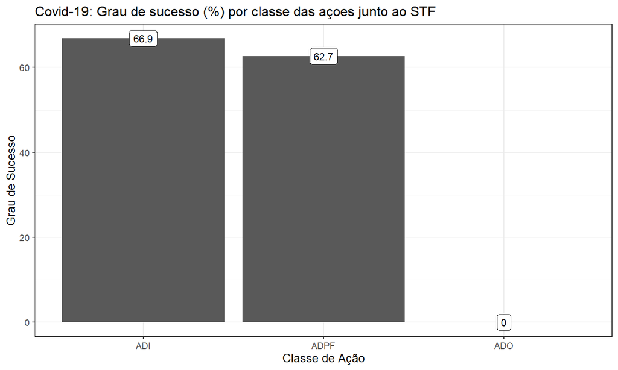

## Análise Descritiva 4

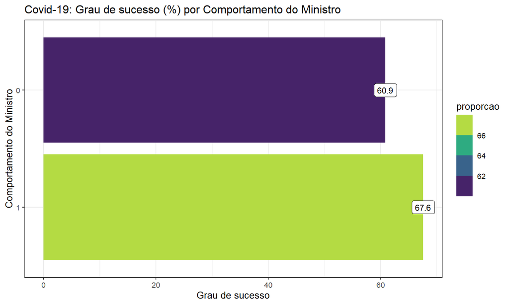

## Visualizando as variáveis

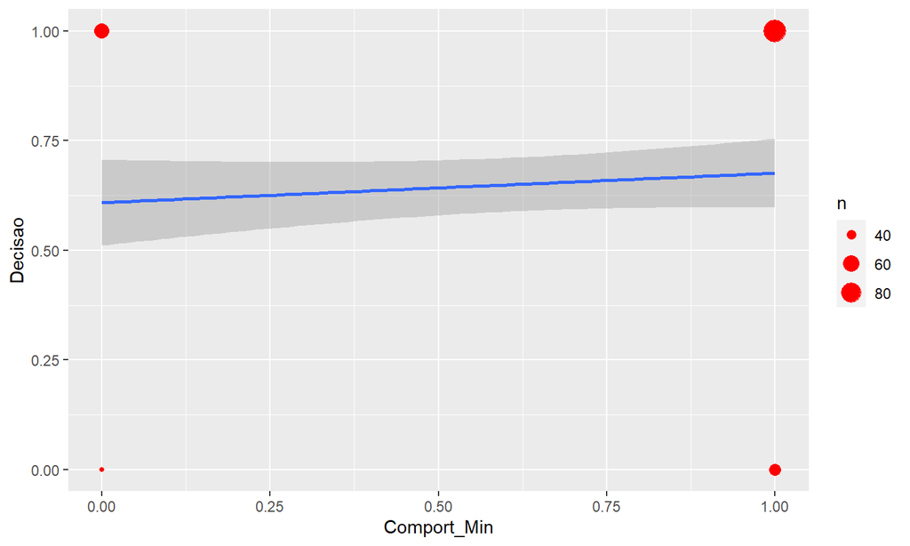

## Rodando o Modelo Logístico: Testando a Hipótese H0

```r
(y <- STF_trabalho_final %>% glm(Decisao~Comport_Min, family = binomial(link="logit"),data = .) %>% summary())
```

```
##
## Call:
## glm(formula = Decisao ~ Comport_Min, family = binomial(link = "logit"),
##     data = .)
##
## Deviance Residuals:
##     Min       1Q   Median       3Q      Max
## -1.5015  -1.3699   0.8849   0.8849   0.9964
##
## Coefficients:
##             Estimate Std. Error z value Pr(>|z|)
## (Intercept)   0.4418     0.2136   2.068   0.0386 *
## Comport_Min   0.2939     0.2789   1.054   0.2920
## ---
## Signif. codes:  0 '***' 0.001 '**' 0.01 '*' 0.05 '.' 0.1 ' ' 1
##
## (Dispersion parameter for binomial family taken to be 1)
##
##     Null deviance: 303.13  on 233  degrees of freedom
## Residual deviance: 302.02  on 232  degrees of freedom
## AIC: 306.02
##
## Number of Fisher Scoring iterations: 4
```

## Ajuste do modelo 1: Anova

```r
y <- STF_trabalho_final %>% glm(Decisao~Comport_Min, family = binomial(link="logit"),data = .)
anova(y,test="Chisq")
```

```
## Analysis of Deviance Table
##
## Model: binomial, link: logit
##
## Response: Decisao
##
## Terms added sequentially (first to last)
##
##
##             Df Deviance Resid. Df Resid. Dev Pr(>Chi)
## NULL                          233     303.13
## Comport_Min  1   1.1073       232     302.02   0.2927
```

## Ajuste do modelo 2: Pseudos R2

```
## $Models
##
## Model: "glm, Decisao ~ Comport_Min, binomial(link = \"logit\"), STF_trabalho_final"
## Null:  "glm, Decisao ~ 1, binomial(link = \"logit\"), STF_trabalho_final"
##
## $Pseudo.R.squared.for.model.vs.null
##                              Pseudo.R.squared
## McFadden                           0.00365283
## Cox and Snell (ML)                 0.00472078
## Nagelkerke (Cragg and Uhler)       0.00650051
##
## $Likelihood.ratio.test
##  Df.diff LogLik.diff  Chisq p.value
##       -1    -0.55364 1.1073 0.29267
##
## $Number.of.observations
##
## Model: 234
## Null:  234
##
## $Messages
## [1] "Note: For models fit with REML, these statistics are based on refitting with ML"
##
## $Warnings
## [1] "None"
```

## Ajuste do modelo 3: Teste Hosmer-Lemeshow

```r
ResourceSelection::hoslem.test(STF_trabalho_final$Decisao, fitted(z))
```

```
##
##  Hosmer and Lemeshow goodness of fit (GOF) test
##
## data:  STF_trabalho_final$Decisao, fitted(z)
## X-squared = 2.3782e-24, df = 8, p-value = 1
```

## Odds Ratio (OR)

```r
# Razão de chance (Oddsratio)

coef(z) %>% exp()
```

```
## (Intercept) Comport_Min
##    1.555556    1.341615
```

## Intervalo de Confiança

```
##                   OR     2.5 %   97.5 %
## (Intercept) 1.555556 1.0283608 2.383277
## Comport_Min 1.341615 0.7751829 2.318432
```

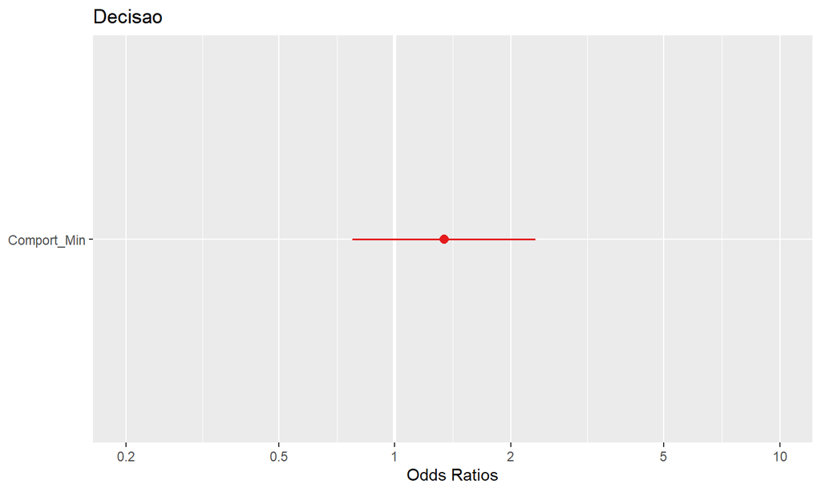

## Visualização do Ajuste

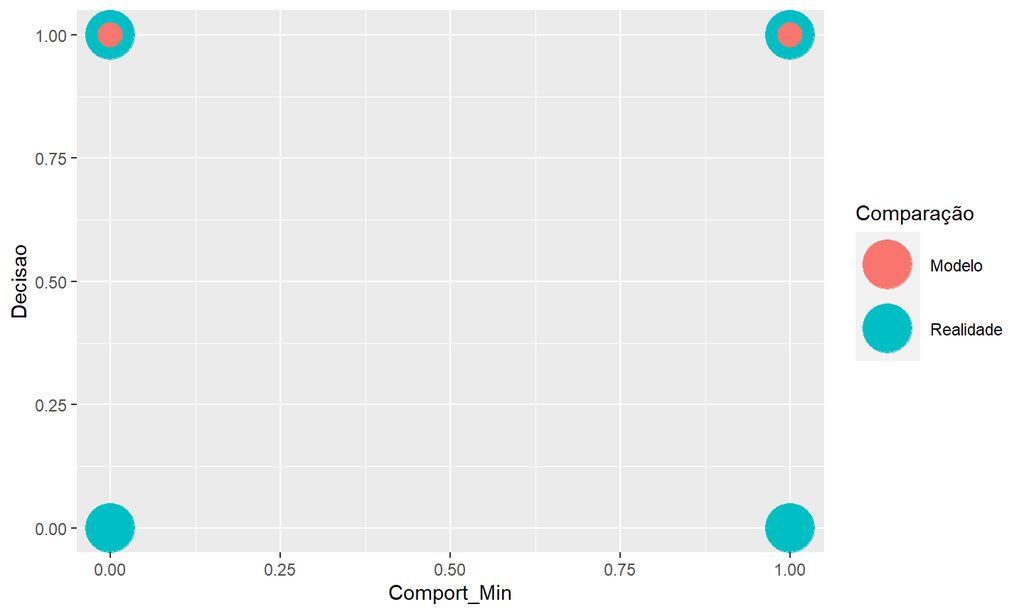

```r
STF_trabalho_final %>% mutate(Decisao_predita=predict(z,type="response")) %>% mutate(Decisao_predita=if_else(Decisao_predita>.5,1,0)) %>% ggplot()+geom_point(aes(x=Comport_Min,y=Decisao,color="Realidade"),size=12) + geom_point(aes(x=Comport_Min,y=Decisao_predita,color="Modelo"),size=6) +guides(color=guide_legend("Comparação"))
```

## Matriz de Confusão

```r
z <- glm(Decisao~Comport_Min, family = binomial(link="logit"),data =STF_trabalho_final)
k <- as.factor(
    ifelse(
        predict(z,
                newdata = STF_trabalho_final,
                type = "response")
        >0.5,"1","0"))
w <- as.factor(STF_trabalho_final$Decisao)
confusionMatrix(k,w,positive="1")
```

```
## Confusion Matrix and Statistics
##
##           Reference
## Prediction   0   1
##          0   0   0
##          1  82 152
##
##                Accuracy : 0.6496
##                  95% CI : (0.5847, 0.7106)
##     No Information Rate : 0.6496
##     P-Value [Acc > NIR] : 0.53
##
##                   Kappa : 0
##
##  Mcnemar's Test P-Value : <2e-16
##
##             Sensitivity : 1.0000
##             Specificity : 0.0000
##          Pos Pred Value : 0.6496
##          Neg Pred Value :    NaN
##              Prevalence : 0.6496
##          Detection Rate : 0.6496
##    Detection Prevalence : 1.0000
##       Balanced Accuracy : 0.5000
##
##        'Positive' Class : 1
##
```

## Curva Roc

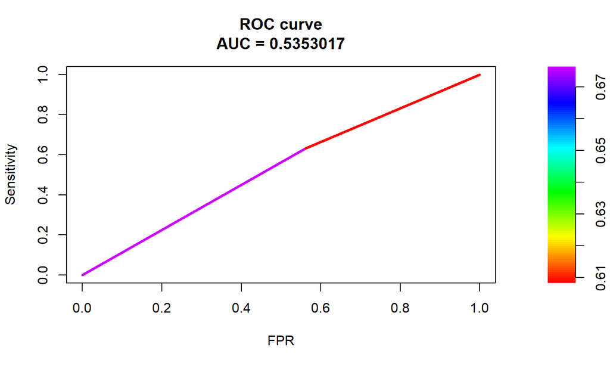

## Conclusões 1

- A pergunta da pesquisa pode ser respondida ao menos parcialmente, haja vista que a hipótese nula de que as decisões do STF, no âmbito das decisões sobre a pandemia da Covid-19, são proferidas com base ou em respeito às forças políticas majoritárias não foi completamente confirmada ao nível de 95% de confiança.
- Apenas o parâmetro b1 não passou no teste de significância (o estimador b0 teve nível de significância menor que 0.05), sendo os efeitos da variável *dummy* comportamento dos ministros do Supremo (Comport_M) sobre as decisções do STF, na sua vertente contramajoritária, compostos pelos dois estimadores (b0 + b1).

## Conclusões 2

- Pode-se afirmar, com as devidas ressalvas, que as chances de uma decisão favorável quando os ministros têm um comportamento contramajoritário (MARCO AURÉLIO, EDSON FACHIN, CARMEM LÚCIA, ROBERTO BARROSO, ROSA WEBER ou LUIZ FUX) aumentam em 34%, comparando-se a um comportamento majoritário de seus membros (representados por GILMAR MENDES, DIAS TOFFOLI, ALEXANDRE DE MORAES, RICARDO LEWANDOSWSKI e NUNES MARQUES).
- Por outro lado, o ajuste do modelo é pouco robusto, pois sua capacidade preditiva dada pelo pseudos R2 é diminuta, o AUC (0,54) é inferior ao aceitável (0,70) e a especificidade é inexistente. De qualquer maneira, o modelo tem um acerto geral de 65% e passou no teste de Hosmer e Lemeshow sobre sua adequação à realidade dos dados